# Introdução ao D3plusR

Paulo Felipe

22 de maio de 2017

# Roteiro

- Introdução
- Instalação
- Conhecendo o D3plus
- Exemplos de visualizações com o D3plusR
- D3plusR e Shiny
- Código JavaScript customizado

# Introdução

# Objetivo

- Apresentar os aspectos básicos do pacote D3plusR

# Sobre o D3plusR

- Utiliza a biblioteca JavaScript D3plus
- D3plus é construída em cima da biblioteca D3
- Gráficos simples e de fácil criação
- Htmlwidgets + D3plus = D3plusR
- Visualizações dinâmicas para documentos (RMarkdown) e aplicações (Shiny)
- Material auxiliar disponível [aqui](http://fulljoin.com.br/tutorial_d3plusr/)

# Instalação

# Instalando o D3plusR

- O pacote está em desenvolvimento
- Disponível apenas no github:

```r
devtools::install_github('paulofelipe/D3plusR')
```

- Demonstração:

```r
vignette("D3plusR")
```

# Conhecendo o D3plus

# Por que é importante conhecer o D3plus?

- Pacotes criados htmlwidgets são apenas interfaces para as bibliotecas originais em JavaScript
- Conhecer a potencialidade da biblioteca original
- Conhecer a documentação e opções

# Projetos que usam D3plus

- [Observatory of Economic Complexity](http://atlas.media.mit.edu/en/)
- [Data USA](https://datausa.io/)
- [DataViva](http://dataviva.info/pt/)
- [Comex Vis](http://www.mdic.gov.br/comercio-exterior/estatisticas-de-comercio-exterior/comex-vis)

# Exemplo de código

- D3plus

```javascript
  var visualization = d3plus.viz()
    .container("#viz")
    .data(data)
    .type("bar")
    .id("name")
    .x("year")
    .y("value")
    .draw()
```

- Transcrevendo para D3plusR

```r
d3plus(data = data, type = "bar",
       id = "name") %>%
  d3plusX("year") %>%
  d3plusY("value")
```

# Exemplo de código (Cont.)

- Métodos: `.type()`, `.id()`, `.x()` etc.
- Métodos mais usados já são argumentos da função `d3plus()` (`data`, `type` e `id`)

> Obs: existe a função `d3plusId()` para configuração de outras opções do id. Possivelmente, todas terão sua função própria.
- Demais: `d3plusX()`, `d3plusY()`, `d3plusTitle()` …

# Estrutura de dados javascript

- Qual é o problema?

```r
.axes({"ticks": false,
       "background": {"color": "#FFFFFF",
                      "stroke": {"width": 0}}})
```

- Em D3plusR:

```r
d3plusAxes(ticks = FALSE,
           background = list(color = "#FFFFFF",
                             stroke = list(width = 0)))
```

- Opções de opções devem ser passadas em listas

# Exemplo de documentação

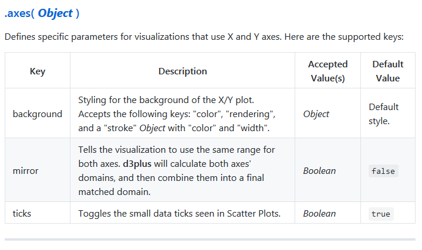

# Exemplos de visualizações com o D3plusR

# Alguns Aspectos Básicos

- Utilizar `Parte1.Rmd`
- Títulos
- Tooltip
- Time
- Locale

# Atributos

- Os atributos são criados em data.frames com os valores de ids e colunas com os valores para cores e ícones
- Se o gráfico tiver mais de um nível (veremos isso adiante), pode ser passada uma lista de data.frames
- Os ícones somente são apresentados para htmls gerados por RMarkdown ou aplicações Shiny

# Formatação de números

- O D3plus aplica uma formatação automática para as variáveis numéricas
- Na função `d3plus()` são fornecidas algumas opções para alterar o comportamento para variáveis de interesse
  - `currency_var`, `currency` e `number_text`
  - `percent_var`
  - `noformat_number_var`

# Dicionário

- É possível criar uma lista com “tradução” de textos.
- Por exemplo: O nome da variável é `VL_FOB`, mas deseja-se que seja apresentada como `Valor Fob`.

# Hierarquia nos dados

- Ver Parte2.Rmd
- Exemplo: Visualizações por Continente e País
- Utilizar a função `d3plusDepth()` para escolher o nível inicial da visualização
- O primeiro nível é definido como 0

# Elemento de interface do usuário

- É possível criar botões e dropdowns com opções que alteram as visualizações
- Deve ser informada uma lista com `method`, `value`, `label` e `type` (apenas os dois primeiros são obrigatórios)
- Os métodos são: size (.size()), color (.color()), title (.title()) etc.

# Mapas

- Arquivos com formato `topojson`
- Duas possibilidades:
  - Importar os dados via `jsonlite`
  - Informar o endereço do arquivo
- Ver `Parte3.Rmd`

# D3plusR e Shiny

# Funções

- `renderD3plus()`: para o Server
- `d3plusOutput()`: para a UI
- Ver exemplo: `app.R`

# Código JavaScript Customizado

# Superando limitações do pacote

- Necessidade de estender o código
- Funções disponíveis:
  - `onRender()`: adiciona código JS na construção do widget (é específico para visualização)
  - `onStaticRenderComplete()`: permite adicionar código JS, mas que precisa ser executado após o carregamento dos widgets

# Interação entre Widgets

- É necessário que os dois widgets estejam carregados antes de executar o código (`onStaticRenderComplete()`)
- Dificuldade: escrever código em JavaScript
- Ver `Parte4.Rmd`

# Obrigado

paulo.alencar@mdic.gov.br